# Financial Inclusion, Digital Trust, and Economic Growth

A Cross-Country Panel Analysis, 2017–2022

2026-03-26

# 1 Introduction

This project investigates how **Financial Inclusion (FI)** relates to **economic growth (GDP)** across a diverse panel of countries between 2017 and 2022, and whether this relationship is moderated by two forms of trust: **Digital Trust (DT)** and **Social Trust (ST)**.

Financial inclusion — access to useful and affordable financial products and services — is widely regarded as a driver of economic development. Yet its impact may not be uniform: it likely depends on the broader institutional and social context in which it occurs. Digital trust (confidence in digital financial systems) and social trust (interpersonal trust within a society) represent two plausible moderating forces. This analysis tests both.

The project proceeds in four stages:

1. **Data preparation** — loading, normalizing, and assembling all variables into a panel dataset.
2. **Exploratory analysis** — visualizing trends and the correlation structure across countries and years.
3. **Panel model estimation** — using Difference GMM to establish the baseline FI → GDP relationship.
4. **Moderation analysis** — testing whether Digital Trust and Social Trust shape the strength of that relationship.

# 2 Setup: Libraries and Helper Functions

```r
library(readxl)
library(tidyverse)
library(reshape2)
library(pheatmap)
library(ggrepel)
library(lme4)
library(broom.mixed)
library(broom)
library(car)
library(plm)
library(lmtest)
library(sandwich)
```

The country-name harmonisation function below is used throughout to ensure consistent naming across data sources.

```r
name_mapping <- list(
  "Hong Kong SAR, China" = "Hong Kong",
  "Macao SAR, China"     = "Macau",
  "Iran, Islamic Rep."   = "Iran",
  "Kyrgyz Republic"      = "Kyrgyzstan",
  "Uzbekistan, Rep. of"  = "Uzbekistan",
  "Russian Federation"   = "Russia",
  "China, P.R.: Mainland"= "China",
  "Hong Kong SAR"        = "Hong Kong",
  "Macau SAR"            = "Macau",
  "Turkiye"              = "Turkey",
  "Viet Nam"             = "Vietnam"
)

simplify_country_name <- function(name) {
  if (name %in% names(name_mapping)) name_mapping[[name]] else name
}
```

# 3 Data Preparation

## 3.1 Financial Inclusion (FI) Data

The FI dataset is sourced from the IMF and contains three sub-dimensions of financial inclusion: **Accessibility**, **Availability**, and **Usage**.

```r
FI_Data_IMF <- read_excel("C:/Poslovi/Vash/New data set/FI Data -.xlsx")
FI_Data_IMF$Code <- gsub("usage", "Usage", FI_Data_IMF$Code)
FI_Data_IMF <- FI_Data_IMF[-nrow(FI_Data_IMF), ]
```

### 3.1.1 Within-country normalisation

Values are normalised to [0, 1] within each country across the 2017–2022 window. This allows intra-country trends to be compared across the three sub-dimensions on a common scale.

$$\text{Normalised Value} = \frac{x -
\min(x)}{\max(x) - \min(x)}$$

```r
for (year in 2017:2022) {
  current_col <- FI_Data_IMF[[as.character(year)]]
  min_val <- apply(FI_Data_IMF[, as.character(2017:2022)], 1, min, na.rm = TRUE)
  max_val <- apply(FI_Data_IMF[, as.character(2017:2022)], 1, max, na.rm = TRUE)
  FI_Data_IMF[[paste0(year, "N")]] <- ifelse(
    is.na(current_col), NA,
    (current_col - min_val) / (max_val - min_val)
  )
}
```

### 3.1.2 FI sub-index aggregation

The three normalised sub-dimensions are averaged within each country and year to form the country-level FI sub-indexes.

```r
FI_Index <- FI_Data_IMF %>%
  filter(!is.na(Code)) %>%
  group_by(`Country Name`, Code) %>%
  summarise(across(ends_with("N"), \(x) mean(x, na.rm = TRUE)), .groups = "drop")
```

## 3.2 Digital Trust (DT) Data

```r
DT <- read_excel("C:/Poslovi/Vash/New data set/DT.xlsx")
colnames(DT)[5:10] <- substr(colnames(DT)[5:10], 1, 4)
```

```r
for (year in 2017:2022) {
  current_col <- DT[[as.character(year)]]
  min_val <- apply(DT[, as.character(2017:2022)], 1, min, na.rm = TRUE)
  max_val <- apply(DT[, as.character(2017:2022)], 1, max, na.rm = TRUE)
  DT[[paste0(year, "N")]] <- (current_col - min_val) / (max_val - min_val)
}

DT_Index <- DT %>%
  group_by(`Country Name`) %>%
  summarise(across(ends_with("N"), \(x) mean(x, na.rm = TRUE)), .groups = "drop") %>%
  mutate(Code = "Digital Trust")
```

## 3.3 Combining FI and DT Indexes

```r
DT_Index <- DT_Index[, colnames(FI_Index)[1:8]]
DT_FI_Combined <- bind_rows(DT_Index, FI_Index)
DT_FI_Combined$`Country Name` <- sapply(DT_FI_Combined$`Country Name`, simplify_country_name)
```

## 3.4 Cross-country normalisation and FII Calculation

The within-country normalisation above facilitates trend analysis but prevents direct cross-country comparisons. Here we re-normalise within each year and across countries, then compute the composite **Financial Inclusion Index (FII)**:

$$\text{FII} = 1 - \frac{1}{3}\left[(1 -
\text{ACI})^2 + (1 - \text{AVI})^2 + (1 -
\text{USI})^2\right]$$

This formula rewards balanced progress across all three sub-dimensions.

```r
FI_Data_IMF <- FI_Data_IMF %>%
  group_by(`Series Name`) %>%
  mutate(across(
    .cols  = as.character(2017:2022),
    .fns   = ~ (. - min(., na.rm = TRUE)) / (max(., na.rm = TRUE) - min(., na.rm = TRUE)),
    .names = "{col}_N_across"
  )) %>%
  ungroup()

FI_Index_Across <- FI_Data_IMF %>%
  filter(!is.na(Code)) %>%
  group_by(`Country Name`, Code) %>%
  summarise(across(ends_with("_N_across"), ~ mean(.x, na.rm = TRUE)), .groups = "drop")

FI_pivot <- FI_Index_Across %>%
  pivot_longer(cols = starts_with("20"), names_to = "Year", values_to = "Value") %>%
  mutate(Year = as.numeric(gsub("_N_across", "", Year))) %>%
  pivot_wider(names_from = Code, values_from = Value) %>%
  mutate(
    FII_across = 1 - (((1 - Accessibility)^2 + (1 - Availability)^2 + (1 - Usage)^2) / 3)
  ) %>%
  rename_with(~ paste0(., "_across"), c("Accessibility", "Availability", "Usage"))
```

## 3.5 Constructing the within-country FI pivot (for trend and correlation analyses)

```r
FI_DT_long <- DT_FI_Combined %>%
  pivot_longer(cols = ends_with("N"), names_to = "Year", values_to = "Value") %>%
  mutate(Year = as.numeric(sub("N", "", Year)))

FI_DT_pivot <- FI_DT_long %>%
  pivot_wider(names_from = Code, values_from = Value) %>%
  mutate(
    FII = 1 - (((1 - Accessibility)^2 + (1 - Availability)^2 + (1 - Usage)^2) / 3)
  )
```

## 3.6 Control Variables

Six macroeconomic control variables are loaded: **GDP per capita** (outcome), **government expenditure (GOV)**, **inflation management efficiency (IMEM)**, **consumer price index (CPI)**, **unemployment (UNEMP)**, and **education index (EDU)**.

```r
read_control <- function(path, value_name) {
  df <- read_excel(path)
  colnames(df)[5:10] <- substr(colnames(df)[5:10], 1, 4)
  if ("Series Code" %in% colnames(df)) colnames(df)[colnames(df) == "Series Code"] <- "Code"
  df$`Country Name` <- sapply(df$`Country Name`, simplify_country_name)
  df %>%
    pivot_longer(cols = `2017`:`2022`, names_to = "Year", values_to = value_name) %>%
    mutate(Year = as.double(Year)) %>%
    select(`Country Name`, Year, all_of(value_name))
}

GDP_long  <- read_control("C:/Poslovi/Vash/GDP Per constant 2015 us dollar.xlsx", "GDP")
GOV_long  <- read_control("C:/Poslovi/Vash/GOV.xlsx",   "GOV")
IMEM_long <- read_control("C:/Poslovi/Vash/IMEM.xlsx",  "IMEM")
CPI_long  <- read_control("C:/Poslovi/Vash/CPI.xlsx",   "CPI")
UNEMP_long<- read_control("C:/Poslovi/Vash/UNEMP.xlsx", "UNEMP")
EDU_long  <- read_control("C:/Poslovi/Vash/EDU.xlsx",   "EDU")
```

## 3.7 Trust Measures

Two additional trust measures are incorporated:

```r
# Social Trust (WVS)
ST <- read_excel("C:/Poslovi/Vash/New data set/Social Trust WVS 2017-2022.xlsx")
ST$Country <- sapply(ST$Country, simplify_country_name)
ST_simplified <- ST %>%
  transmute(`Country Name` = Country, ST = `Most People Can Be Trusted`)

# Trust in Banks (Gallup)
TiB <- read_excel("Trust in Banks.xlsx") %>%
  mutate(
    TiB_numeric = (as.numeric(`A Great Deal (%)`) * 4 +
                   as.numeric(`Quite a Lot (%)`)  * 3 +
                   as.numeric(`Not Very Much (%)`) * 2 +
                   as.numeric(`None at All (%)`))  / 400,
    TiB_high    = as.numeric(`A Great Deal (%)`)
  ) %>%
  select(Country, TiB_numeric, TiB_high) %>%
  rename(`Country Name` = Country) %>%
  mutate(`Country Name` = sapply(`Country Name`, simplify_country_name))

# Cybersecurity Index
CSI <- read_excel("DT -Cybersecurity index.xlsx") %>%
  filter(year < 2023, year > 2016) %>%
  rename(Year = year) %>%
  mutate(`Country Name` = sapply(`Country Name`, simplify_country_name))
```

## 3.8 Full Panel Dataset

All components are joined into a single panel dataframe with country and year as the panel identifiers.

```r
Full_data <- FI_DT_pivot %>%
  inner_join(FI_pivot,   by = c("Country Name", "Year")) %>%
  inner_join(GOV_long,   by = c("Country Name", "Year")) %>%
  inner_join(IMEM_long,  by = c("Country Name", "Year")) %>%
  inner_join(CPI_long,   by = c("Country Name", "Year")) %>%
  inner_join(UNEMP_long, by = c("Country Name", "Year")) %>%
  inner_join(EDU_long,   by = c("Country Name", "Year")) %>%
  inner_join(GDP_long,   by = c("Country Name", "Year")) %>%
  left_join(ST_simplified, by = "Country Name") %>%
  inner_join(CSI,  by = c("Country Name", "Year")) %>%
  left_join(TiB,   by = "Country Name") %>%
  mutate(across(-`Country Name`, as.numeric))

Full_data[Full_data == ".."] <- NA
```

## 3.9 Standardisation

All numeric variables are standardised (z-scored) prior to modelling. This ensures coefficients are directly comparable across variables and eliminates scale-driven bias in the GMM estimator.

```r
Full_data_standardized <- Full_data %>%
  mutate(across(where(is.numeric) & !starts_with("year"),
                ~ as.numeric(scale(.)))) %>%
  rename_with(~ gsub("\\[.*,.*\\]", "", .)) %>%
  rename(Country_Name = `Country Name`)

write.csv(Full_data,             "Full data.csv",             row.names = FALSE)
write.csv(Full_data_standardized,"Full data standardized.csv",row.names = FALSE)
```

# 4 Exploratory Data Analysis

## 4.1 Descriptive Statistics

```r
descriptives_overall <- Full_data %>%
  select(`Digital Trust`:ST, -Year) %>%
  summarise(across(where(is.numeric), list(
    Mean   = ~ mean(.,   na.rm = TRUE),
    Median = ~ median(., na.rm = TRUE),
    SD     = ~ sd(.,     na.rm = TRUE),
    Min    = ~ min(.,    na.rm = TRUE),
    Max    = ~ max(.,    na.rm = TRUE)
  ), .names = "{col}_{fn}"))

descriptives_country <- Full_data %>%
  select(`Country Name`:`ST`, -Year) %>%
  group_by(`Country Name`) %>%
  summarise(across(where(is.numeric), list(
    Mean   = ~ mean(.,   na.rm = TRUE),
    Median = ~ median(., na.rm = TRUE),
    SD     = ~ sd(.,     na.rm = TRUE),
    Min    = ~ min(.,    na.rm = TRUE),
    Max    = ~ max(.,    na.rm = TRUE)
  ), .names = "{col}_{fn}"))

descriptives_year <- Full_data %>%
  select(`Country Name`:`ST`) %>%
  group_by(Year) %>%
  summarise(across(where(is.numeric), list(
    Mean = ~ mean(., na.rm = TRUE),
    SD   = ~ sd(.,   na.rm = TRUE)
  ), .names = "{col}_{fn}"))

write.csv(descriptives_country, "Descriptives by country.csv", row.names = FALSE)
write.csv(descriptives_year,    "Yearly descriptives.csv",     row.names = FALSE)
write.csv(descriptives_overall, "Overall descriptives.csv",    row.names = FALSE)
```

## 4.2 Index Trends Over Time by Country

The following chart plots all four normalised sub-indexes (Accessibility, Availability, Usage, Digital Trust) over time for each country. Within-country normalisation means that the y-axis reflects change relative to each country’s own range rather than absolute cross-country standing.

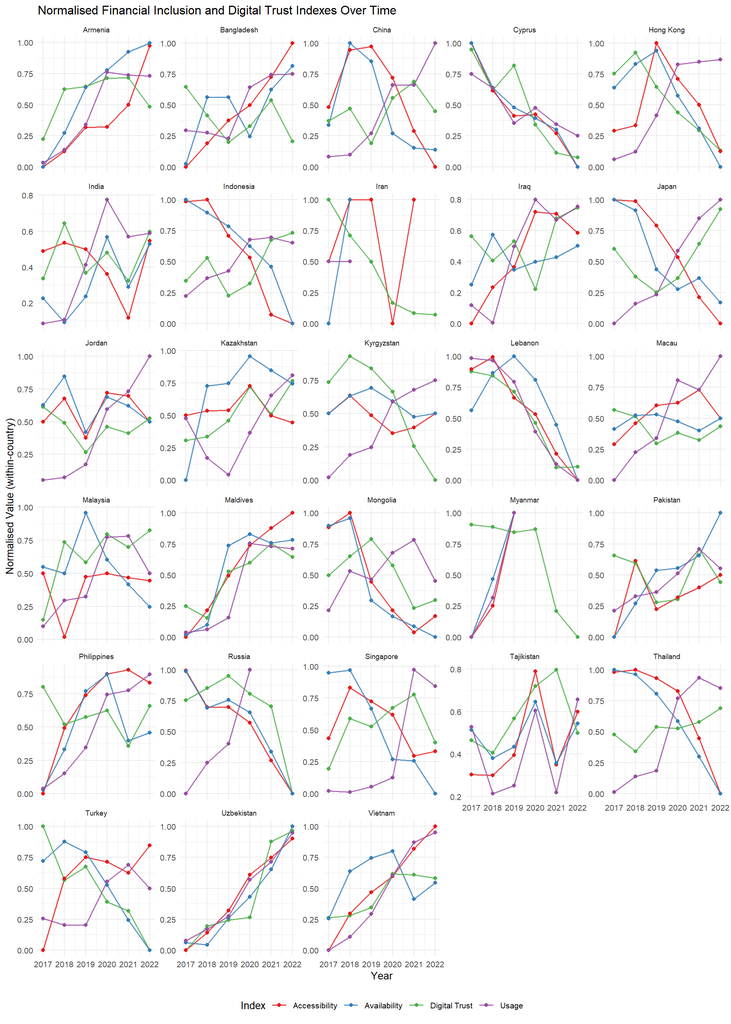

```r
ggplot(FI_DT_long, aes(x = Year, y = Value, color = Code)) +
  geom_line(aes(group = interaction(`Country Name`, Code)), alpha = 0.8, linewidth = 0.7) +
  geom_point(size = 1.5) +
  facet_wrap(~ `Country Name`, scales = "free_y", ncol = 5) +
  scale_color_brewer(palette = "Set1") +
  theme_minimal(base_size = 10) +
  labs(
    title  = "Normalised Financial Inclusion and Digital Trust Indexes Over Time",
    x      = "Year",
    y      = "Normalised Value (within-country)",
    color  = "Index"
  ) +
  theme(legend.position = "bottom", strip.text = element_text(size = 7))
```

## 4.3 Average Correlation Among Sub-Indexes

To understand which indexes tend to move together, a correlation matrix is computed for each country separately and then averaged across all countries.

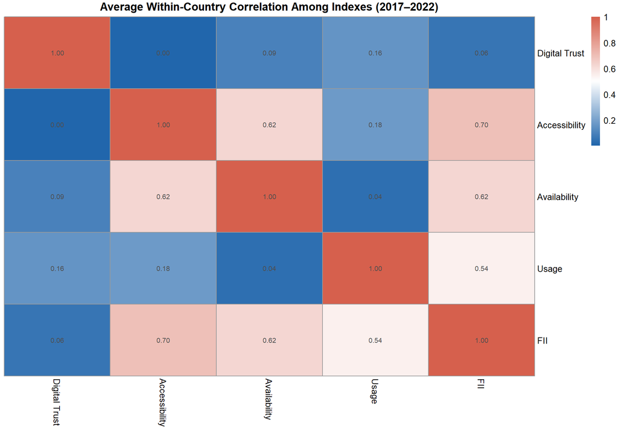

```r
countries <- unique(FI_DT_pivot$`Country Name`)
cor_matrices <- list()

for (country in countries) {
  country_data <- FI_DT_pivot %>%
    filter(`Country Name` == country) %>%
    select(-`Country Name`, -Year) %>%
    na.omit()
  if (ncol(country_data) > 1 && nrow(country_data) > 2) {
    cor_matrices[[country]] <- cor(country_data, use = "complete.obs")
  }
}

common_dim <- ncol(cor_matrices[[1]])
cor_matrices <- cor_matrices[sapply(cor_matrices, ncol) == common_dim]
cor_array    <- array(unlist(cor_matrices),
                      dim = c(common_dim, common_dim, length(cor_matrices)))
avg_cor      <- apply(cor_array, c(1, 2), mean, na.rm = TRUE)
rownames(avg_cor) <- colnames(avg_cor) <- colnames(cor_matrices[[1]])

pheatmap(avg_cor,
         cluster_rows    = FALSE,
         cluster_cols    = FALSE,
         display_numbers = TRUE,
         number_format   = "%.2f",
         main            = "Average Within-Country Correlation Among Indexes (2017–2022)",
         color           = colorRampPalette(c("#2166ac","white","#d6604d"))(100))
```

## 4.4 FII Trends Over Time

Using the cross-country FII (which supports international comparisons), we can observe how the composite index evolved in each country.

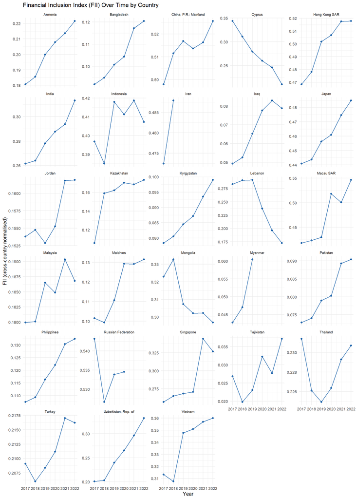

```r
ggplot(FI_pivot, aes(x = Year, y = FII_across)) +
  geom_line(aes(group = `Country Name`), color = "#2166ac", alpha = 0.8, linewidth = 0.7) +
  geom_point(size = 1.5, color = "#2166ac") +
  facet_wrap(~ `Country Name`, scales = "free_y", ncol = 5) +
  theme_minimal(base_size = 10) +
  labs(
    title = "Financial Inclusion Index (FII) Over Time by Country",
    x     = "Year",
    y     = "FII (cross-country normalised)"
  ) +
  theme(strip.text = element_text(size = 7))
```

## 4.5 FII and GDP Cross-Country Relationship

A simple scatter plot of country-averaged FII against country-averaged GDP gives a first impression of their association.

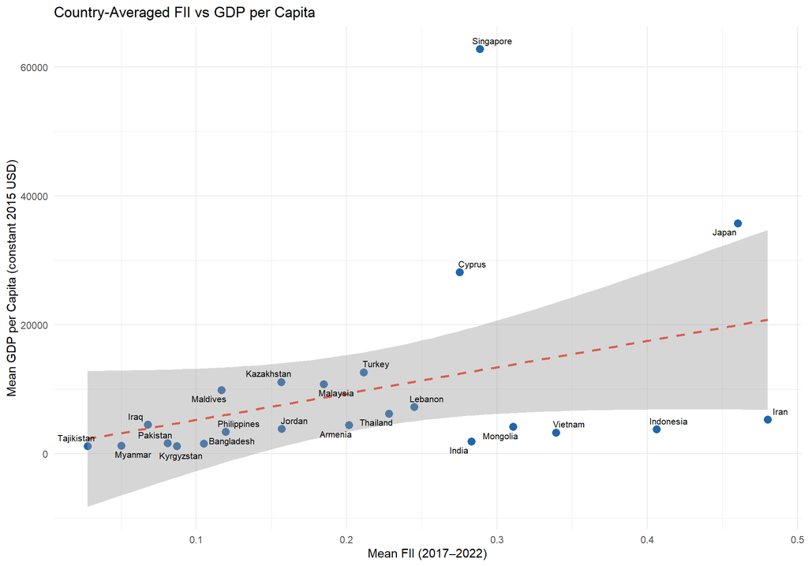

```r
ggplot(descriptives_country,
       aes(x = FII_across_Mean, y = GDP_Mean, label = `Country Name`)) +
  geom_point(color = "#2166ac", size = 3) +
  geom_smooth(method = "lm", color = "#d6604d", se = TRUE, linetype = "dashed") +
  geom_text_repel(size = 2.8, max.overlaps = 20) +
  labs(
    title = "Country-Averaged FII vs GDP per Capita",
    x     = "Mean FII (2017–2022)",
    y     = "Mean GDP per Capita (constant 2015 USD)"
  ) +
  theme_minimal()
```

## 4.6 Macro-Variable Correlation Structure

The following heatmap shows how all variables relate to each other within countries over time (intra-country, time-series correlations averaged across countries).

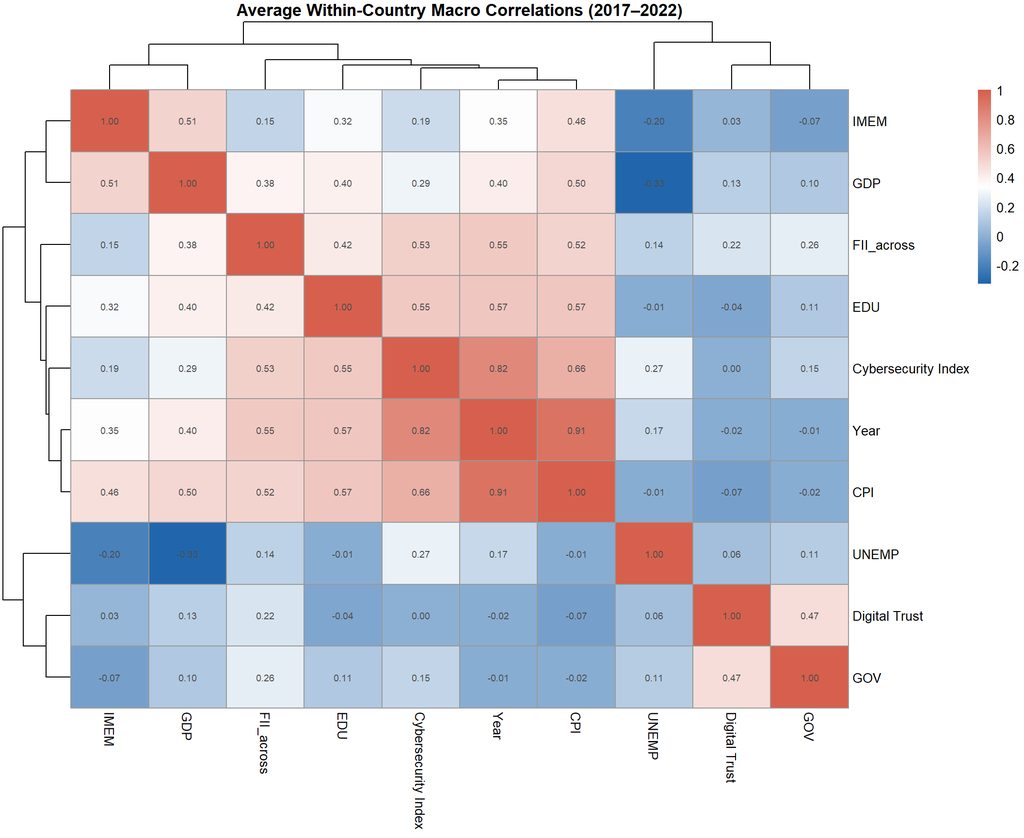

```r
cor_matrices_full <- list()

for (country in unique(Full_data_standardized$Country_Name)) {
  country_data <- Full_data_standardized %>%
    filter(Country_Name == country) %>%
    select(-c(Country_Name, starts_with("..."),
              Accessibility:Usage_across, ST, TiB_numeric, TiB_high)) %>%
    na.omit()
  if (ncol(country_data) > 1 && nrow(country_data) > 2)
    cor_matrices_full[[country]] <- cor(country_data, use = "complete.obs")
}

common_dim_f  <- ncol(cor_matrices_full[[1]])
cor_matrices_full <- cor_matrices_full[sapply(cor_matrices_full, ncol) == common_dim_f]
cor_array_full <- array(unlist(cor_matrices_full),
                        dim = c(common_dim_f, common_dim_f, length(cor_matrices_full)))
avg_cor_full   <- apply(cor_array_full, c(1, 2), mean, na.rm = TRUE)
rownames(avg_cor_full) <- colnames(avg_cor_full) <- colnames(cor_matrices_full[[1]])

pheatmap(avg_cor_full,
         cluster_rows    = TRUE,
         cluster_cols    = TRUE,
         display_numbers = TRUE,
         number_format   = "%.2f",
         main            = "Average Within-Country Macro Correlations (2017–2022)",
         color           = colorRampPalette(c("#2166ac","white","#d6604d"))(100),
         fontsize_number = 7)
```

**Interpretation:** Several patterns stand out. CPI has a strong positive association with Year, GDP, and EDU, consistent with nominal growth over time. FII correlates positively with GDP, EDU, and CPI. IMEM shows a strong positive relationship with GDP and CPI, and a moderate negative one with UNEMP. GDP correlates strongly with FII, IMEM, CPI, and EDU and moderately negatively with UNEMP. Digital Trust has a notable positive correlation with GOV (governance quality), a weaker one with FII, and little relationship with the remaining variables.

## 4.7 Variable Trends Over Time

The plots below track how each variable evolved annually, both at the country level and averaged across all countries.

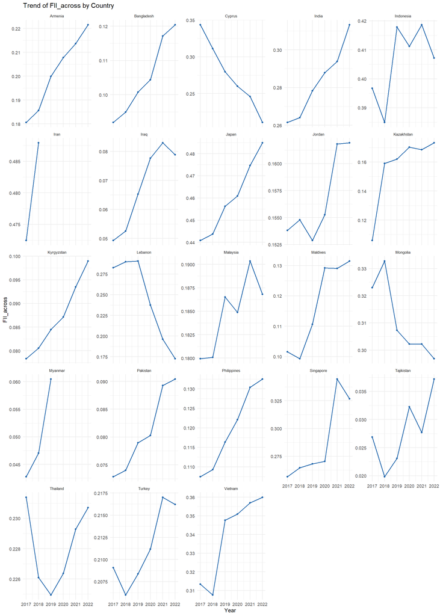

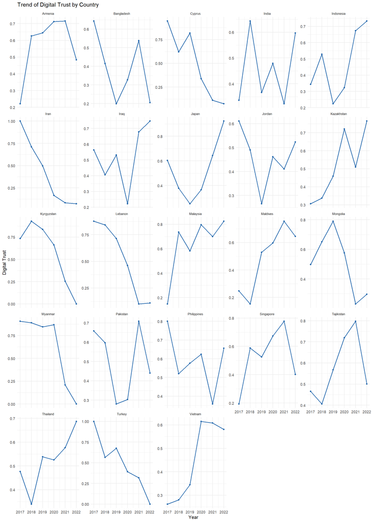

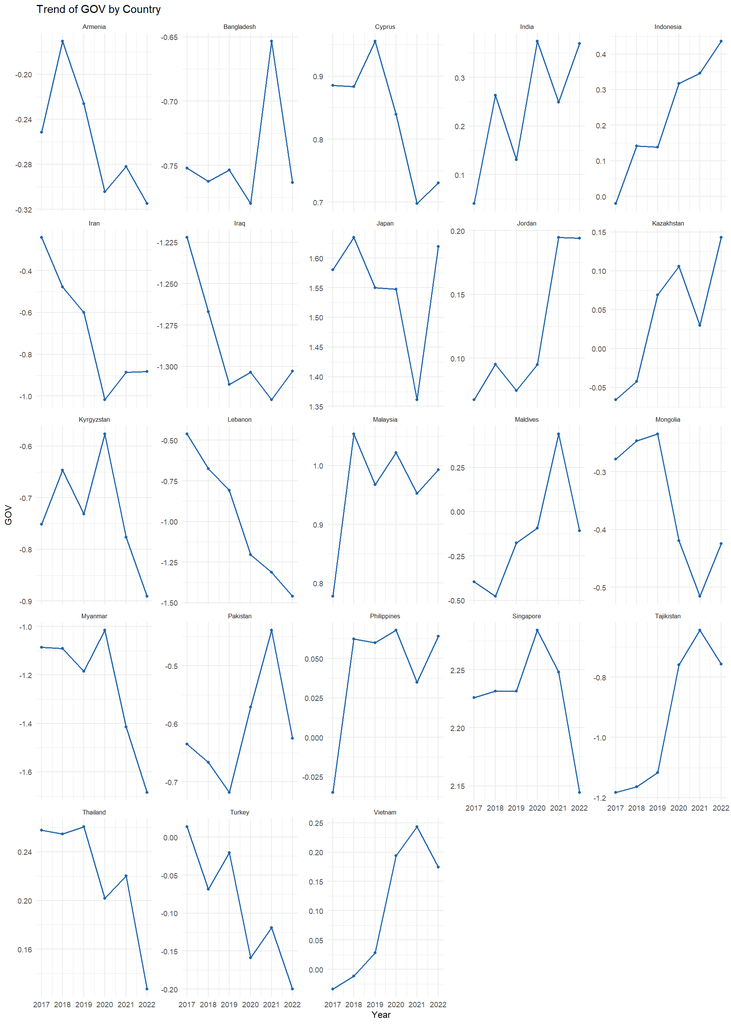

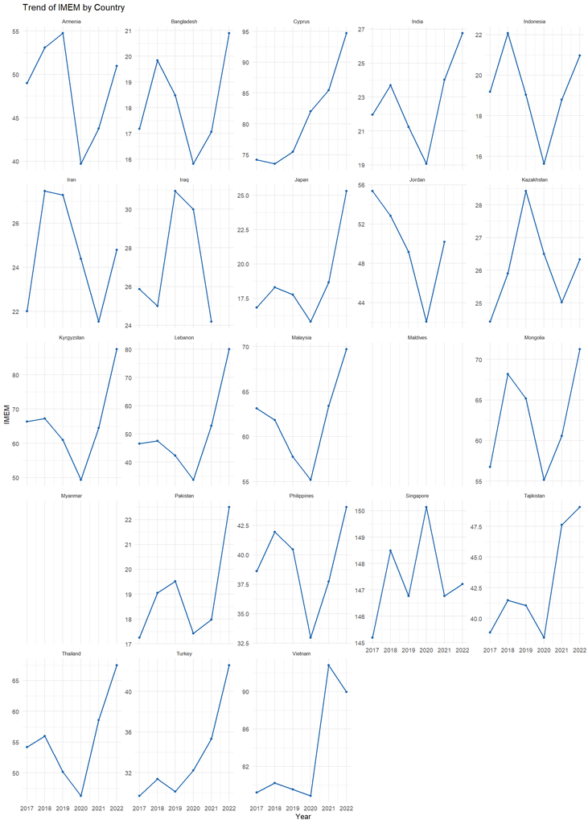

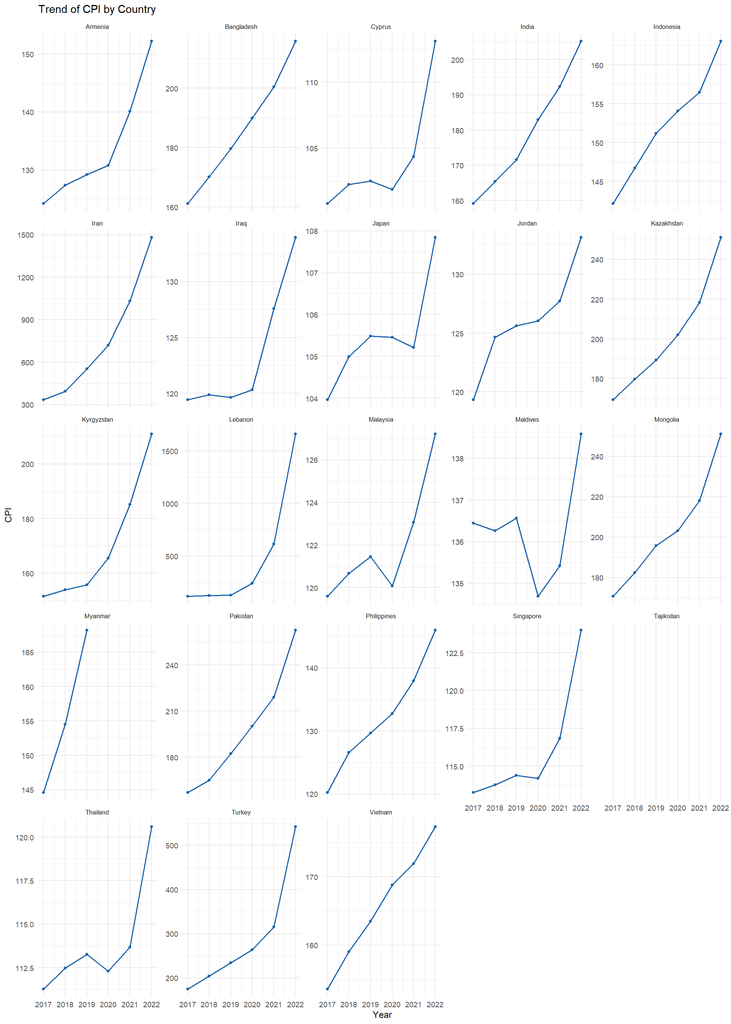

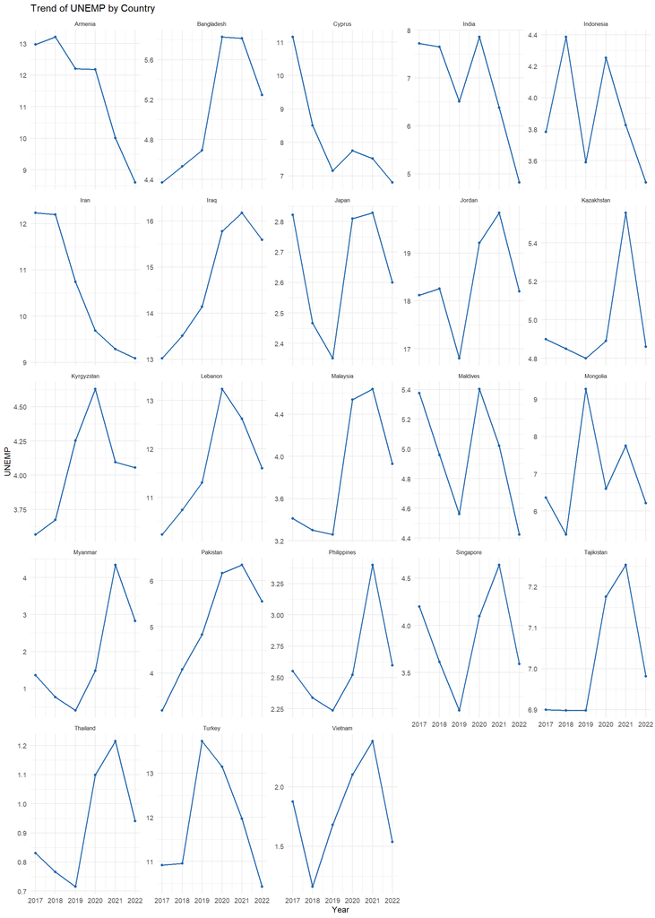

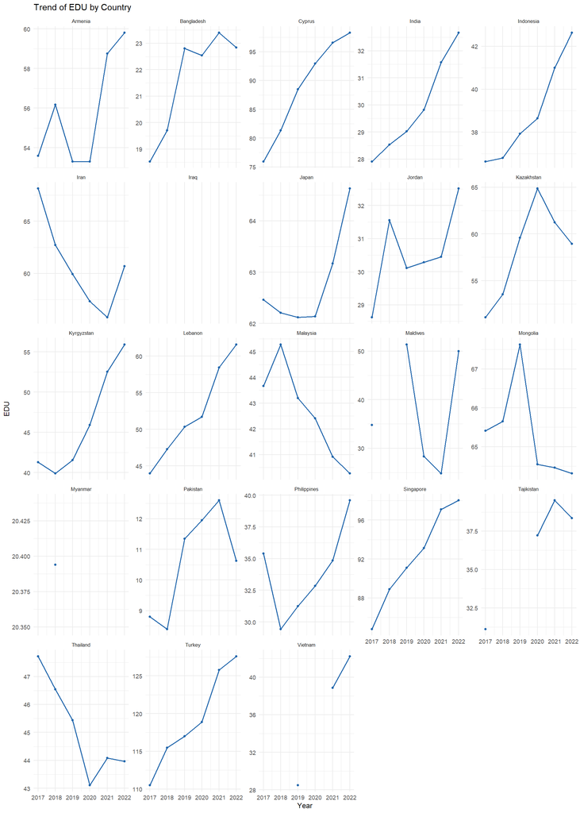

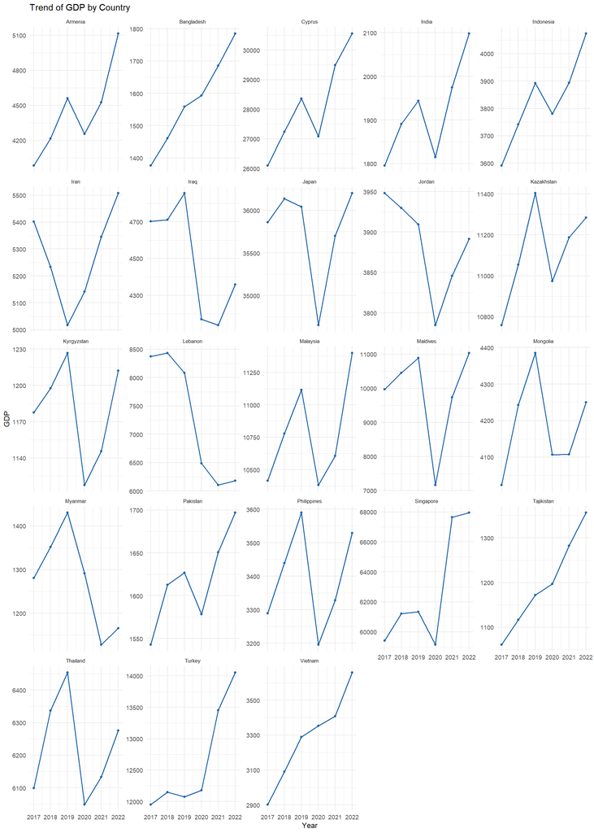

```r
trend_vars <- c("FII_across", "Digital Trust", "GOV", "IMEM", "CPI", "UNEMP", "EDU", "GDP")

for (var in trend_vars) {
  p <- ggplot(Full_data, aes(x = Year, y = .data[[var]])) +
    geom_line(color = "#2166ac", linewidth = 0.6) +
    geom_point(size = 1, color = "#2166ac") +
    facet_wrap(~ `Country Name`, ncol = 5, scales = "free_y") +
    labs(title = paste("Trend of", var, "by Country"), x = "Year", y = var) +
    theme_minimal(base_size = 9) +
    theme(strip.text = element_text(size = 6.5))
  print(p)
}
```

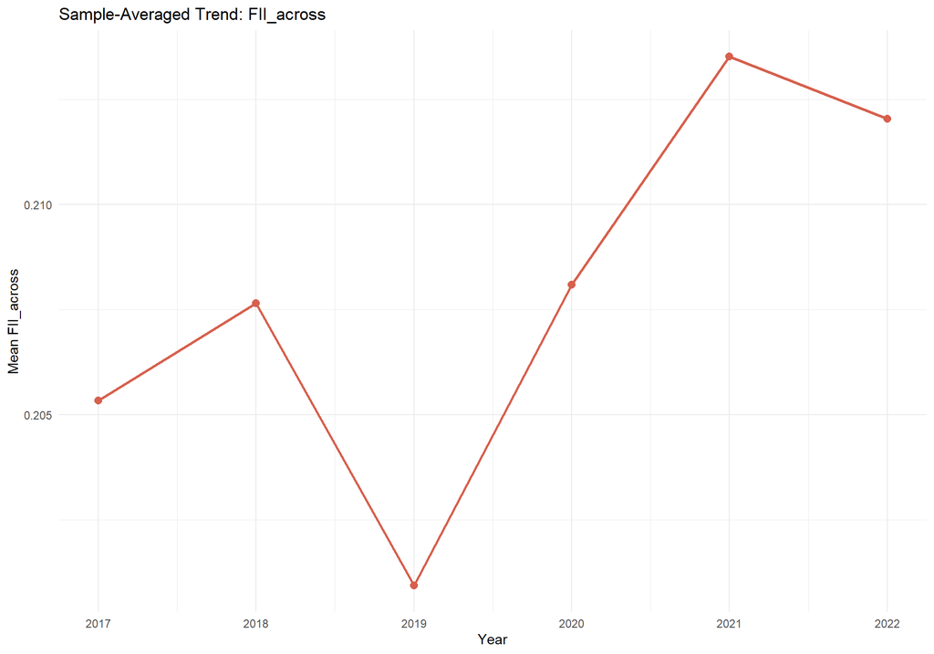

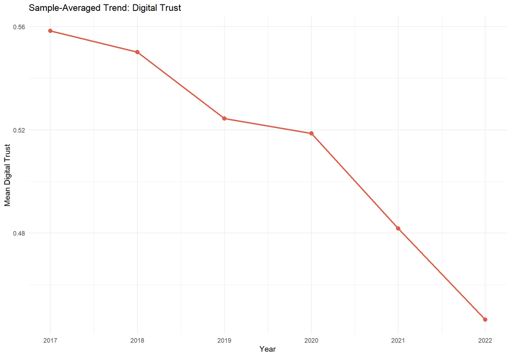

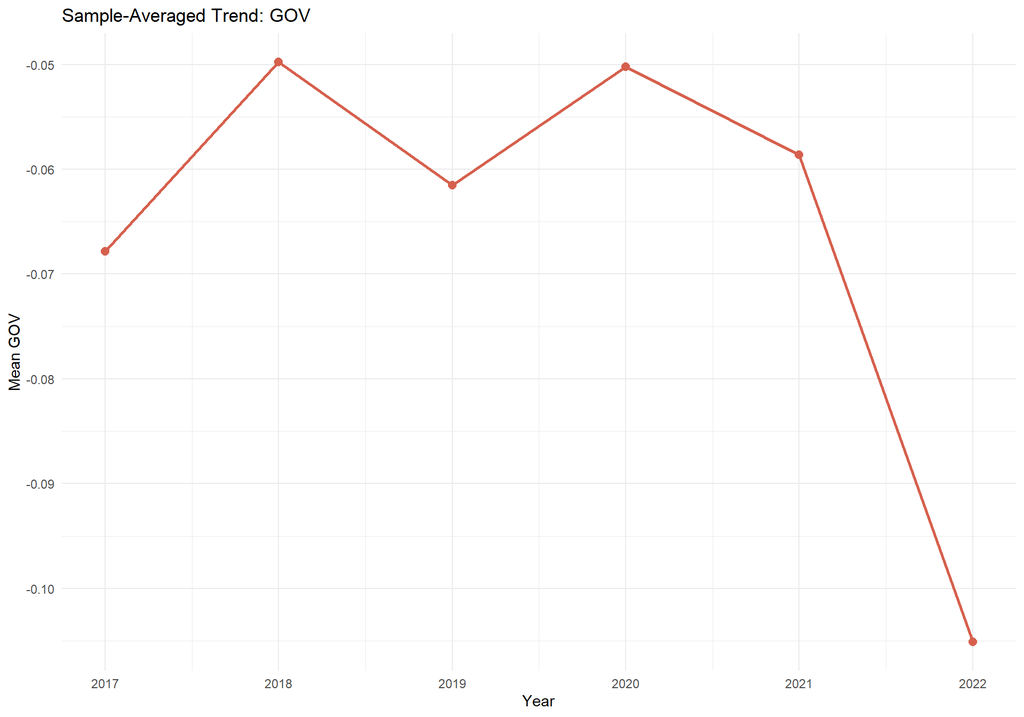

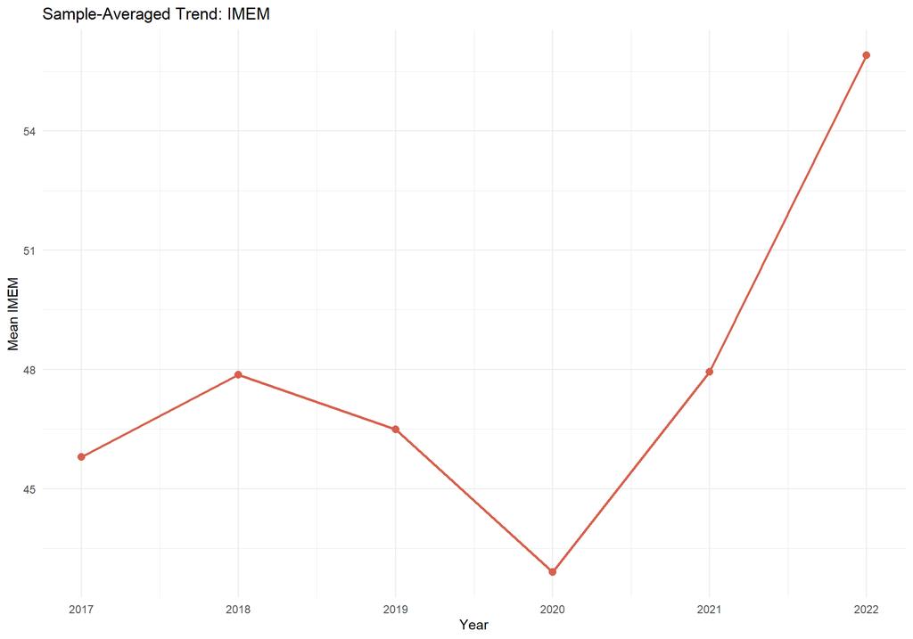

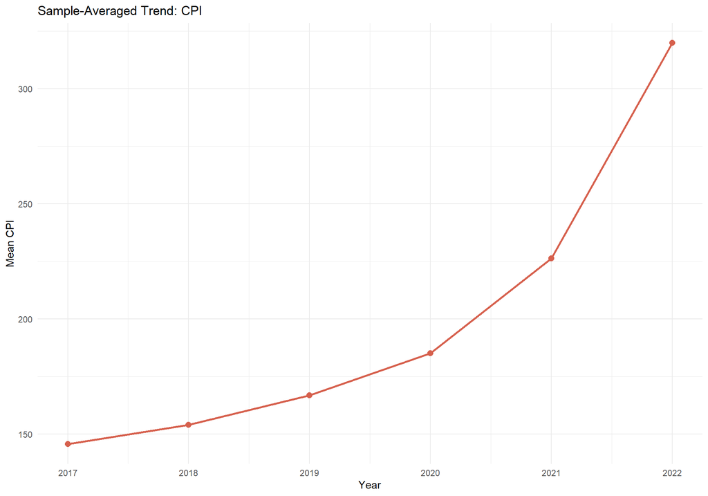

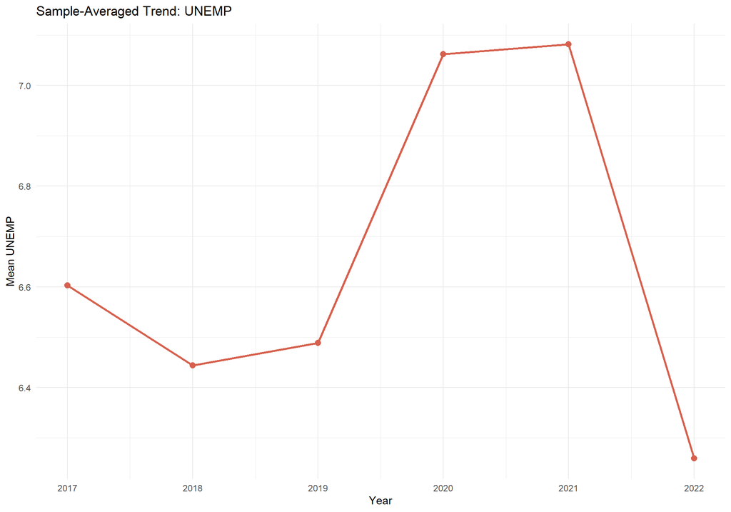

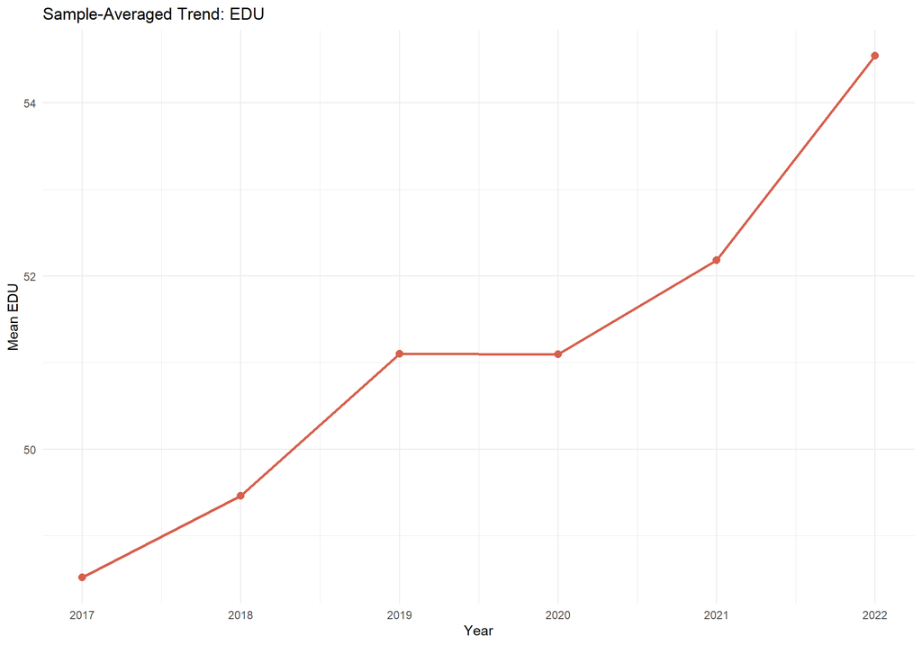

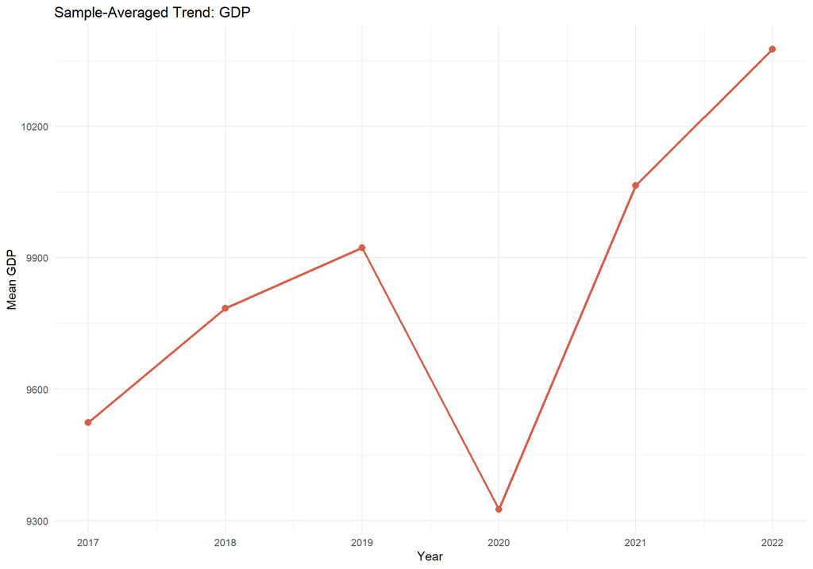

```r
for (var in trend_vars) {
  avg_data <- Full_data %>%
    group_by(Year) %>%
    summarise(avg = mean(.data[[var]], na.rm = TRUE))
  p <- ggplot(avg_data, aes(x = Year, y = avg)) +
    geom_line(color = "#d6604d", linewidth = 1) +
    geom_point(size = 2.5, color = "#d6604d") +
    labs(title  = paste("Sample-Averaged Trend:", var),
         x = "Year", y = paste("Mean", var)) +
    theme_minimal()
  print(p)
}
```

# 5 Panel Data Models

## 5.1 Data Preparation for Panel Estimation

```r
pdata <- pdata.frame(Full_data_standardized, index = c("Country_Name", "Year"))
```

## 5.2 Model 1 — Simple Dynamic Panel (FII only)

The first model estimates the direct effect of financial inclusion on GDP using a **two-step Difference GMM** estimator. Lagged GDP controls for persistence in economic output, and lagged values of both GDP and FII serve as instruments, addressing potential endogeneity. Both individual (country) and time effects are accounted for.

$$\text{GDP}_{it} = \alpha \cdot
\text{GDP}_{i,t-1} + \beta \cdot \text{FII}_{it} + \eta_i + \lambda_t +
\varepsilon_{it}$$

```r
simple_model <- pgmm(
  GDP ~ lag(GDP, 1) + FII_across | lag(GDP, 2:5) + lag(FII_across, 2:5),
  data    = pdata,
  effect  = "twoway",
  model   = "twostep",
  collapse= TRUE
)
summary(simple_model, robust = TRUE)
```

```
## Twoways effects Two-steps model Difference GMM
##
## Call:
## pgmm(formula = GDP ~ lag(GDP, 1) + FII_across | lag(GDP, 2:5) +
##     lag(FII_across, 2:5), data = pdata, effect = "twoway", model = "twostep",
##     collapse = TRUE)
##
## Balanced Panel: n = 23, T = 6, N = 138
##
## Number of Observations Used: 85
## Residuals:
##      Min.   1st Qu.    Median      Mean   3rd Qu.      Max.
## -0.350600 -0.043089  0.000000  0.009876  0.037627  0.356340
##
## Coefficients:
##             Estimate Std. Error z-value Pr(>|z|)
## lag(GDP, 1)  0.58259    0.40881  1.4251  0.15413
## FII_across   0.86989    0.40099  2.1694  0.03005 *
## ---
## Signif. codes:  0 '***' 0.001 '**' 0.01 '*' 0.05 '.' 0.1 ' ' 1
##
## Sargan test: chisq(6) = 7.360549 (p-value = 0.28879)
## Autocorrelation test (1): normal = 0.4577399 (p-value = 0.64714)
## Autocorrelation test (2): normal = 1.365322 (p-value = 0.17215)
## Wald test for coefficients: chisq(2) = 5.298697 (p-value = 0.070697)
## Wald test for time dummies: chisq(4) = 13.52623 (p-value = 0.0089712)
```

## 5.3 Model 2 — Full Dynamic Panel (FII + Controls)

Control variables — CPI, UNEMP, EDU, and GOV — are added to isolate the effect of financial inclusion from other macroeconomic forces.

$$\text{GDP}_{it} = \alpha \cdot
\text{GDP}_{i,t-1} + \beta_1 \cdot \text{FII}_{it} + \beta_2 \cdot
\text{CPI}_{it} + \beta_3 \cdot \text{UNEMP}_{it} + \beta_4 \cdot
\text{EDU}_{it} + \beta_5 \cdot \text{GOV}_{it} + \eta_i + \lambda_t +
\varepsilon_{it}$$

```r
full_model <- pgmm(
  GDP ~ lag(GDP, 1) + FII_across + CPI + UNEMP + EDU + GOV |
    lag(GDP, 2:5) + lag(FII_across, 2:5),
  data    = pdata,
  effect  = "twoways",
  model   = "twostep",
  collapse= TRUE
)
summary(full_model, robust = TRUE)
```

```
## Twoways effects Two-steps model Difference GMM
##
## Call:
## pgmm(formula = GDP ~ lag(GDP, 1) + FII_across + CPI + UNEMP +
##     EDU + GOV | lag(GDP, 2:5) + lag(FII_across, 2:5), data = pdata,
##     effect = "twoways", model = "twostep", collapse = TRUE)
##
## Balanced Panel: n = 23, T = 6, N = 138
##
## Number of Observations Used: 72
## Residuals:
##       Min.    1st Qu.     Median       Mean    3rd Qu.       Max.
## -0.2077457 -0.0409997 -0.0003448 -0.0004807  0.0106256  0.3320831
##
## Coefficients:
##              Estimate Std. Error z-value Pr(>|z|)
## lag(GDP, 1)  0.439477   0.380820  1.1540  0.24849
## FII_across   0.836624   0.378651  2.2095  0.02714 *
## CPI          0.052581   0.032452  1.6203  0.10517
## UNEMP        0.059045   0.046910  1.2587  0.20814
## EDU          0.170253   0.070839  2.4034  0.01624 *
## GOV         -0.035615   0.152953 -0.2329  0.81588
## ---
## Signif. codes:  0 '***' 0.001 '**' 0.01 '*' 0.05 '.' 0.1 ' ' 1
##
## Sargan test: chisq(6) = 7.904149 (p-value = 0.24521)
## Autocorrelation test (1): normal = -0.2589987 (p-value = 0.79564)
## Autocorrelation test (2): normal = 1.124662 (p-value = 0.26073)
## Wald test for coefficients: chisq(6) = 20.32755 (p-value = 0.002421)
## Wald test for time dummies: chisq(4) = 10.01767 (p-value = 0.040131)
```

## 5.4 Model 3 — Moderation by Digital Trust and Social Trust

Interaction terms are added to test whether Digital Trust (DT) and Social Trust (ST) moderate the FII → GDP relationship.

```r
full_model_interactions <- pgmm(
  GDP ~ lag(GDP, 1) + FII_across + CPI + UNEMP + EDU + GOV +
    FII_across:`Digital.Trust` + FII_across:ST |
    lag(GDP, 2:5) + lag(FII_across, 2:5),
  data    = pdata,
  effect  = "twoways",
  model   = "twostep",
  collapse= TRUE
)
summary(full_model_interactions, robust = TRUE)
```

```
## Twoways effects Two-steps model Difference GMM
##
## Call:
## pgmm(formula = GDP ~ lag(GDP, 1) + FII_across + CPI + UNEMP +
##     EDU + GOV + FII_across:Digital.Trust + FII_across:ST | lag(GDP,
##     2:5) + lag(FII_across, 2:5), data = pdata, effect = "twoways",
##     model = "twostep", collapse = TRUE)
##
## Balanced Panel: n = 23, T = 6, N = 138
##
## Number of Observations Used: 72
## Residuals:
##       Min.    1st Qu.     Median       Mean    3rd Qu.       Max.
## -0.2177928 -0.0194768  0.0000000  0.0002093  0.0101922  0.2516660
##
## Coefficients:
##                            Estimate Std. Error z-value  Pr(>|z|)
## lag(GDP, 1)               0.1743348  0.1222701  1.4258   0.15392
## FII_across                0.4977220  0.1176286  4.2313 2.323e-05 ***
## CPI                       0.0168340  0.0105005  1.6032   0.10890
## UNEMP                     0.0278779  0.0332475  0.8385   0.40175
## EDU                       0.1146397  0.0758594  1.5112   0.13073
## GOV                      -0.0226801  0.1011468 -0.2242   0.82258
## FII_across:Digital.Trust -0.0043938  0.0086861 -0.5058   0.61297
## FII_across:ST             0.1798008  0.0786292  2.2867   0.02221 *
## ---
## Signif. codes:  0 '***' 0.001 '**' 0.01 '*' 0.05 '.' 0.1 ' ' 1
##
## Sargan test: chisq(6) = 8.395059 (p-value = 0.21056)
## Autocorrelation test (1): normal = -0.7923131 (p-value = 0.42818)
## Autocorrelation test (2): normal = 0.9035764 (p-value = 0.36622)
## Wald test for coefficients: chisq(8) = 65.0825 (p-value = 4.6482e-11)
## Wald test for time dummies: chisq(4) = 11.47406 (p-value = 0.021722)
```

# 6 Moderation Analysis: Year-by-Year Cross-Sections

While the GMM models pool information across time, cross-sectional OLS regressions estimated separately for each year reveal whether the moderating effects are stable or emerge at specific points. All models include the same set of controls; VIF, Breusch-Pagan, and Shapiro-Wilk diagnostics are recorded for each year.

## 6.1 Digital Trust (and Cybersecurity Index) as Moderator

```r
diagnostics_csi <- list()

for (yr in unique(Full_data_standardized$Year)) {
  data_yr <- Full_data_standardized %>% filter(Year == yr)
  model_yr <- lm(
    GDP ~ FII_across * `Cybersecurity Index` + FII_across * TiB_high +
          CPI + UNEMP + EDU + GOV,
    data = data_yr
  )
  diagnostics_csi[[as.character(yr)]] <- list(
    summary     = summary(model_yr),
    vif         = vif(model_yr, type = "predictor"),
    bp_test     = bptest(model_yr),
    shapiro     = shapiro.test(residuals(model_yr))
  )
}

for (yr in names(diagnostics_csi)) {
  cat("\n=== Year:", yr, "===\n")
  print(diagnostics_csi[[yr]])
}
```

```
##
## === Year: 2017 ===
## $summary
##
## Call:
## lm(formula = GDP ~ FII_across * `Cybersecurity Index` + FII_across *
##     TiB_high + CPI + UNEMP + EDU + GOV, data = data_yr)
##
## Residuals:
##      Min       1Q   Median       3Q      Max
## -0.48402 -0.17875 -0.07312  0.10921  0.59971
##
## Coefficients:
##                                  Estimate Std. Error t value Pr(>|t|)
## (Intercept)                      -0.21250    0.18821  -1.129  0.28807
## FII_across                       -0.18492    0.17574  -1.052  0.32013
## `Cybersecurity Index`            -0.44632    0.25599  -1.743  0.11522
## TiB_high                          0.02604    0.17805   0.146  0.88695
## CPI                               0.71113    0.64745   1.098  0.30056
## UNEMP                            -0.11884    0.13436  -0.884  0.39944
## EDU                               0.15171    0.17998   0.843  0.42111
## GOV                               1.38580    0.31060   4.462  0.00157 **
## FII_across:`Cybersecurity Index`  0.01378    0.19987   0.069  0.94656
## FII_across:TiB_high              -0.14516    0.13265  -1.094  0.30222
## ---
## Signif. codes:  0 '***' 0.001 '**' 0.01 '*' 0.05 '.' 0.1 ' ' 1
##
## Residual standard error: 0.4338 on 9 degrees of freedom
##   (4 observations deleted due to missingness)
## Multiple R-squared:  0.9131, Adjusted R-squared:  0.8261
## F-statistic:  10.5 on 9 and 9 DF,  p-value: 0.0008626
##
##
## $vif
##                         GVIF Df GVIF^(1/(2*Df))                  Interacts With
## FII_across          9.265125  3        1.449245 `Cybersecurity Index`, TiB_high
## Cybersecurity Index 3.232319  1        1.797865                      FII_across
## TiB_high            9.265125  3        1.449245                      FII_across
## CPI                 2.372734  1        1.540368                            --
## UNEMP               1.762589  1        1.327625                            --
```

[output cut: 369 more lines]

```
##
## $bp_test
##
##  studentized Breusch-Pagan test
##
## data:  model_yr
## BP = 9.5542, df = 9, p-value = 0.3878
##
##
## $shapiro
##
##  Shapiro-Wilk normality test
##
## data:  residuals(model_yr)
## W = 0.9356, p-value = 0.2194
```

**Interpretation:** The interaction terms for both the Cybersecurity Index and Trust in Banks fail to reach significance in any individual year. This is consistent with the GMM finding: Digital Trust, in its various operationalisations, does not reliably moderate the FII–GDP relationship on a year-by-year basis. This may reflect that digital trust effects operate over longer time horizons, or that the chosen indicators do not fully capture the construct.

## 6.2 Social Trust as Moderator

```r
results_st <- list()

for (yr in unique(Full_data_standardized$Year)) {
  data_yr <- Full_data_standardized %>% filter(Year == yr)
  model_yr <- lm(
    GDP ~ FII_across * ST + CPI + UNEMP + EDU + GOV,
    data = data_yr
  )
  results_st[[as.character(yr)]] <- broom::tidy(model_yr) %>%
    mutate(Year = yr)
}

results_st_df <- bind_rows(results_st)

results_st_df %>%
  filter(term == "FII_across:ST") %>%
  select(Year, term, estimate, std.error, statistic, p.value) %>%
  knitr::kable(digits = 3, caption = "Year-by-Year FII × Social Trust Interaction")
```

Year-by-Year FII × Social Trust Interaction

| Year | term | estimate | std.error | statistic | p.value |
| --- | --- | --- | --- | --- | --- |
| 2017 | FII_across:ST | -0.032 | 0.118 | -0.274 | 0.789 |
| 2018 | FII_across:ST | 0.007 | 0.151 | 0.047 | 0.963 |
| 2019 | FII_across:ST | -0.002 | 0.126 | -0.017 | 0.986 |
| 2020 | FII_across:ST | 0.077 | 0.139 | 0.554 | 0.592 |
| 2021 | FII_across:ST | 0.164 | 0.123 | 1.342 | 0.207 |
| 2022 | FII_across:ST | 0.104 | 0.131 | 0.791 | 0.445 |

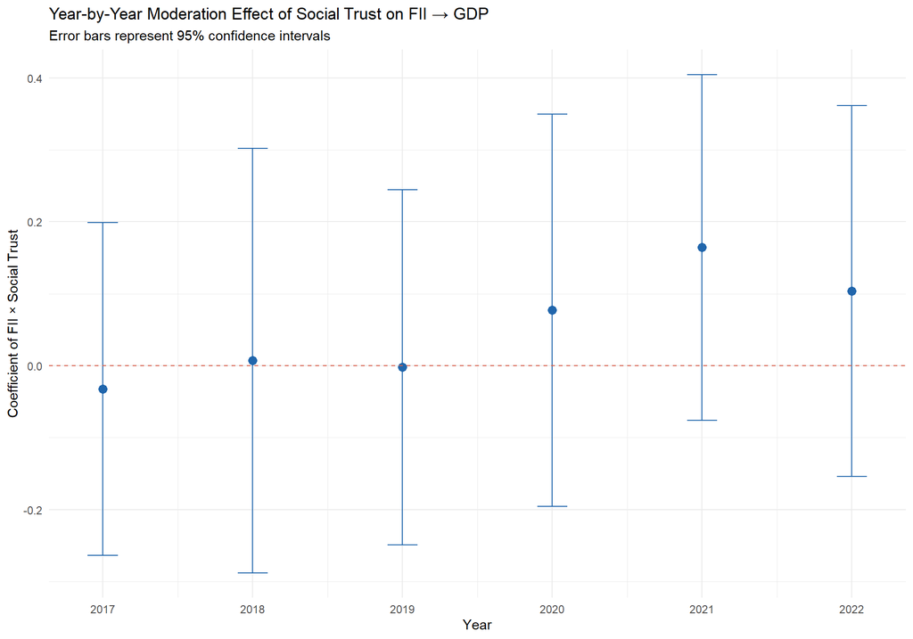

```r
results_st_df %>%
  filter(term == "FII_across:ST") %>%
  ggplot(aes(x = Year, y = estimate)) +
  geom_point(size = 3, color = "#2166ac") +
  geom_errorbar(
    aes(ymin = estimate - 1.96 * std.error,
        ymax = estimate + 1.96 * std.error),
    width = 0.2, color = "#2166ac"
  ) +
  geom_hline(yintercept = 0, linetype = "dashed", color = "#d6604d") +
  labs(
    title    = "Year-by-Year Moderation Effect of Social Trust on FII → GDP",
    subtitle = "Error bars represent 95% confidence intervals",
    x        = "Year",
    y        = "Coefficient of FII × Social Trust"
  ) +
  theme_minimal()
```

**Interpretation:** Across all individual years (2017–2022), the interaction coefficient for FII × Social Trust fluctuates around zero and does not reach significance in any single year. This contrasts with the significant panel (longitudinal) effect found in Model 3. The divergence indicates that the moderating role of Social Trust requires the full temporal dimension of the panel to be detected — it accumulates over time rather than being observable in any given cross-section.

# 7 Fixed vs. Random Effects: Model Selection

To confirm the appropriate estimator for the panel moderation models, a Hausman test is conducted to choose between fixed and random effects.

```r
panel_data <- pdata.frame(Full_data_standardized, index = c("Country_Name", "Year"))

fe_model <- plm(
  GDP ~ FII_across * Digital.Trust + FII_across * ST + CPI + UNEMP + EDU + GOV,
  data  = panel_data,
  model = "within"
)

re_model <- plm(
  GDP ~ FII_across * Digital.Trust + FII_across * ST + CPI + UNEMP + EDU + GOV,
  data  = panel_data,
  model = "random"
)

phtest(fe_model, re_model)
```

```
##
##  Hausman Test
##
## data:  GDP ~ FII_across * Digital.Trust + FII_across * ST + CPI + UNEMP +  ...
## chisq = 37.453, df = 8, p-value = 9.498e-06
## alternative hypothesis: one model is inconsistent
```

The Hausman test is significant, indicating that country-specific effects are correlated with the regressors, so the **fixed-effects model** is preferred.

```r
summary(fe_model)
```

```
## Oneway (individual) effect Within Model
##
## Call:
## plm(formula = GDP ~ FII_across * Digital.Trust + FII_across *
##     ST + CPI + UNEMP + EDU + GOV, data = panel_data, model = "within")
##
## Unbalanced Panel: n = 21, T = 1-6, N = 113
##
## Residuals:
##      Min.   1st Qu.    Median   3rd Qu.      Max.
## -0.167268 -0.016308  0.001460  0.019568  0.151801
##
## Coefficients:
##                            Estimate Std. Error t-value  Pr(>|t|)
## FII_across                0.1723838  0.0378960  4.5489 1.800e-05 ***
## Digital.Trust            -0.0087464  0.0075412 -1.1598  0.249405
## CPI                      -0.0244830  0.0099204 -2.4680  0.015617 *
## UNEMP                    -0.0593166  0.0272157 -2.1795  0.032094 *
## EDU                       0.0968027  0.0360174  2.6877  0.008674 **
## GOV                       0.0376213  0.0467777  0.8043  0.423518
## FII_across:Digital.Trust -0.0057460  0.0065872 -0.8723  0.385534
## FII_across:ST             0.2049313  0.0279087  7.3429 1.232e-10 ***
## ---
## Signif. codes:  0 '***' 0.001 '**' 0.01 '*' 0.05 '.' 0.1 ' ' 1
##
## Total Sum of Squares:    0.58961
## Residual Sum of Squares: 0.23766
## R-Squared:      0.59691
## Adj. R-Squared: 0.46255
## F-statistic: 15.5488 on 8 and 84 DF, p-value: 8.4562e-14
```

```r
# Heteroskedasticity
bptest(fe_model)
```

```
##
##  studentized Breusch-Pagan test
##
## data:  fe_model
## BP = 17.514, df = 9, p-value = 0.04125
```

```r
# Serial correlation
pbgtest(fe_model)
```

```
##
##  Breusch-Godfrey/Wooldridge test for serial correlation in panel models
##
## data:  GDP ~ FII_across * Digital.Trust + FII_across * ST + CPI + UNEMP +  ...
## chisq = 1.6885, df = 1, p-value = 0.1938
## alternative hypothesis: serial correlation in idiosyncratic errors
```

Since the Breusch-Pagan test detects heteroskedasticity, robust (HC1) standard errors are applied to ensure valid inference.

```r
fe_robust <- coeftest(fe_model, vcov = vcovHC(fe_model, type = "HC1"))
print(fe_robust)
```

```
##
## t test of coefficients:
##
##                            Estimate Std. Error t value Pr(>|t|)
## FII_across                0.1723838  0.0892486  1.9315 0.056793 .
## Digital.Trust            -0.0087464  0.0066186 -1.3215 0.189923
## CPI                      -0.0244830  0.0079753 -3.0699 0.002884 **
## UNEMP                    -0.0593166  0.0281580 -2.1066 0.038139 *
## EDU                       0.0968027  0.0507726  1.9066 0.059992 .
## GOV                       0.0376213  0.0486697  0.7730 0.441696
## FII_across:Digital.Trust -0.0057460  0.0068789 -0.8353 0.405914
## FII_across:ST             0.2049313  0.0741479  2.7638 0.007019 **
## ---
## Signif. codes:  0 '***' 0.001 '**' 0.01 '*' 0.05 '.' 0.1 ' ' 1
```

**Fixed-effects model results (with robust SEs):**

- **FII × Social Trust** remains positive and significant, confirming the longitudinal moderating role of Social Trust.
- **FII × Digital Trust** does not reach significance, consistent with all previous results.
- **CPI and UNEMP** show negative effects on GDP, and **EDU** a marginal positive effect, all consistent with economic theory.

# 8 Discussion and Conclusions

## 8.1 Summary of Findings

**Moderation by Social Trust:** Social trust consistently amplifies the FII → GDP relationship in longitudinal models. Countries with higher baseline levels of interpersonal trust derive greater economic benefits from financial inclusion. This moderating effect is not detectable in year-by-year cross-sections alone — it requires the panel dimension to emerge, suggesting it accumulates over multiple years.

**Moderation by Digital Trust:** Digital Trust — measured as a composite DT index, a cybersecurity index, or trust in banks — does not significantly moderate the FII–GDP relationship in any model or timeframe tested. This may reflect that existing digital trust indicators are imperfect proxies for the underlying construct, or that digital trust’s influence on economic outcomes operates through indirect channels.

## 8.2 Comparison of DT and ST as Moderators

| Dimension | Digital Trust | Social Trust |
| --- | --- | --- |
| Year-specific moderation | Not significant | Not significant |
| Longitudinal moderation | Not significant | **Significant (+)** |
| Nature | Time-varying | Time-invariant (stable) |
| Mechanism | Infrastructure / confidence | Institutional embeddedness |

## 8.3 Recommendations

**For policymakers:**

- Efforts to expand financial inclusion should be paired with investments in social cohesion — community trust acts as a multiplier of inclusion’s economic benefits.
- Improving digital infrastructure and financial literacy may help unlock the potential moderating role of digital trust that this study was unable to confirm statistically.

**For future research:**

- Extend the panel beyond 2022 to capture post-pandemic dynamics and the impact of Central Bank Digital Currencies (CBDCs).
- Explore non-linear relationships between FII and GDP — inclusion effects may be largest at intermediate levels of financial development.
- Use more granular trust measures (e.g., institution-specific digital trust, sub-national social trust) to better identify the mechanisms through which trust shapes inclusion’s economic impact.
- Consider machine learning methods (e.g., causal forests) to detect heterogeneous treatment effects across country subgroups.

*Analysis conducted in R. Data sources: IMF Financial Access Survey, World Values Survey, World Bank World Development Indicators, Gallup World Poll, and the Global Cybersecurity Index.*